# Personal Information

Name: **Amber Stoevelaar**

StudentID: **14009749**

Email: **amber.stoevelaar@student.uva.nl**

Submitted on: **22.03.2025**

# Data Context

The data used in this research consists of three datasets collected from Dutch primary schools. The first dataset captures student preferences, gathered through surveys in which students indicate peers they would like to be grouped with. The second dataset contains additional student information, such as gender and the need for extra educational support. The third dataset includes constraints and teacher preferences, specifying conditions such as mandatory or restricted student pairings and ensuring a balanced gender distribution.

These datasets originate from real-world school administration records. Teachers collect student preferences through surveys, while additional student information is recorded based on school records. Constraints and teacher preferences are determined by the teachers themselves based on their requirements. The data is stored in an Excel file and provided to researchers for analysis.

# Data Description

In the exploratory data analysis (EDA) of the student grouping dataset, we found that the dataset consists of 77 students, with 43 boys and 34 girls. The students are nearly equally distributed between grade 4 (40 students) and grade 5 (37 students). Most students provided five preferences, with one student giving none and five students providing between one and four preferences. Visual analysis of the preference data revealed 3 to 4 distinct clusters, suggesting natural groupings among students, which could help guide the sorting process.

```python
import numpy as np
import pandas as pd
import networkx as nx
import pandas as pd
import random
import matplotlib.pyplot as plt
```

The data first was anonymized by giving each student an id. The data was then checked for mistakes. Several mistakes were found in the data, these were manual errors made by the teachers when collecting the data. These mistakes were corrected by changing the incorrect form of the names to the name given with the id. This process was carried out manually by the researchers, as automation could not reliably identify all mistakes due to their inconsistent nature.

As a result, the corrected data ensures greater accuracy and consistency in the dataset, reducing errors that could affect analysis.

```python
# Load your data here
preferences = pd.read_csv('Data/Preferences.csv', sep=';')
student_info = pd.read_csv('Data/StudentInfo.csv', sep=';')
constraints = pd.read_csv('Data/Constraints.csv', sep=';')

# Max 5 preferences per student
preferences = preferences[['ID', 'Preference_1', 'Preference_2', 'Preference_3', 'Preference_4', 'Preference_5']]

df = pd.merge(student_info, preferences, on='ID')
df
```

|  | ID | Gender | Group | Preference_1 | Preference_2 | Preference_3 | Preference_4 | Preference_5 |
| --- | --- | --- | --- | --- | --- | --- | --- | --- |
| 0 | S01 | f | 4 | S06 | S17 | S22 | S16 | S18 |
| 1 | S02 | f | 4 | S47 | S20 | S21 | S18 | S74 |
| 2 | S03 | m | 4 | S18 | S05 | S04 | S14 | S19 |
| 3 | S04 | m | 4 | S03 | S19 | S15 | S14 | S05 |
| 4 | S05 | m | 4 | S14 | S19 | S03 | S15 | NaN |
| ... | ... | ... | ... | ... | ... | ... | ... | ... |
| 72 | S73 | f | 5 | S53 | S76 | S52 | S72 | S68 |
| 73 | S74 | m | 5 | S55 | S70 | S65 | S76 | S52 |
| 74 | S75 | f | 5 | S71 | S57 | S77 | S58 | S53 |
| 75 | S76 | m | 5 | S70 | S55 | S74 | S65 | S73 |
| 76 | S77 | m | 5 | S72 | S59 | S56 | S52 | S68 |

77 rows × 8 columns

### 1. Corpus

```python
# Shape of the datasets
print('Shape of the datasets:')
print('Students:', df.shape)
print('Constraints:', constraints.shape)

# Number of variables in each dataset
print('Number of variables in each dataset:')
print('Students:', df.shape[1])
print('Constraints:', constraints.shape[1])

# Number of observations in each dataset
print('Number of observations in each dataset:')
print('Students:', df.shape[0])
print('Constraints:', constraints.shape[0])

# Check for missing values
print('Missing values in each dataset:')
print('Students:', df.isnull().sum().sum())
print('Constraints:', constraints.isnull().sum().sum())

# Check for duplicates
print('Duplicates in each dataset:')
print('Students:', df.duplicated().sum())
print('Constraints:', constraints.duplicated().sum())
```

```
Shape of the datasets:
Students: (77, 8)
Constraints: (11, 3)
Number of variables in each dataset:
Students: 8
Constraints: 3
Number of observations in each dataset:
Students: 77
Constraints: 11
Missing values in each dataset:
Students: 11
Constraints: 0
Duplicates in each dataset:
Students: 0
Constraints: 0
```

```python
# Summary statistics
print('Summary statistics:')
print('Students:', df.describe(include='all'))
print('Constraints:', constraints.describe())
```

```
Summary statistics:
Students:          ID Gender      Group Preference_1 Preference_2 Preference_3  \
count    77     77  77.000000           76           76           76
unique   77      2        NaN           51           46           48
top     S01      m        NaN          S67          S48          S42
freq      1     43        NaN            3            5            4
mean    NaN    NaN   4.480519          NaN          NaN          NaN
std     NaN    NaN   0.502897          NaN          NaN          NaN
min     NaN    NaN   4.000000          NaN          NaN          NaN
25%     NaN    NaN   4.000000          NaN          NaN          NaN
50%     NaN    NaN   4.000000          NaN          NaN          NaN
75%     NaN    NaN   5.000000          NaN          NaN          NaN
max     NaN    NaN   5.000000          NaN          NaN          NaN

       Preference_4 Preference_5
count            75           71
unique           48           42
top             S59          S68
freq              3            4
mean            NaN          NaN
std             NaN          NaN
min             NaN          NaN
25%             NaN          NaN
50%             NaN          NaN
75%             NaN          NaN
max             NaN          NaN
Constraints:        Constraint Student_1 Student_2
count          11        11        11
unique          1         8         8
top       Exclude       S07       S12
freq           11         2         2
```

### 2. Variables

```python
# List all features
print('Features in the students dataset:')
print(df.columns)
print('Features in the constraints dataset:')
print(constraints.columns)
```

```
Features in the students dataset:
Index(['ID', 'Gender', 'Group', 'Preference_1', 'Preference_2', 'Preference_3',
       'Preference_4', 'Preference_5'],
      dtype='object')
Features in the constraints dataset:
Index(['Constraint', 'Student_1', 'Student_2'], dtype='object')
```

```python
# Number of students
n_students = student_info.shape[0]

print('Number of students:', n_students)
# Number of students per gender
print('Number of students per gender:')
students_gender = df['Gender'].value_counts()
print(students_gender)

# Number of students per grade
students_per_grade = df['Group'].value_counts()
print('Number of students per grade:')
print(students_per_grade)
```

```
Number of students: 77
Number of students per gender:
Gender
m    43
f    34
Name: count, dtype: int64
Number of students per grade:
Group
4    40
5    37
Name: count, dtype: int64
```

```python
# Number of preferences
n_preferences = preferences.iloc[:, 1:].count().sum()

# Number of constraints (rows)
n_constraints = constraints.shape[0]

# Number of exclude constraints
n_exclude = constraints[constraints['Constraint'] == 'Exclude'].shape[0]

# Number of include constraints
n_include = constraints[constraints['Constraint'] == 'Include'].shape[0]

print('Number of preferences:', n_preferences)
print('Number of constraints:', n_constraints)
print('Number of exclude constraints:', n_exclude)
print('Number of include constraints:', n_include)
```

```
Number of preferences: 374
Number of constraints: 11
Number of exclude constraints: 11
Number of include constraints: 0
```

```python
# Print number of student with 5 preferences, number of students with 4 preferences, etc.
n_students = preferences.shape[0]
n_pref = preferences.iloc[:, 1:].count(axis=1).value_counts().sort_index()
n_pref = n_pref.reindex(range(6), fill_value=0)
print('Number of students with 5 preferences:', n_pref[5])
print('Number of students with 4 preferences:', n_pref[4])
print('Number of students with 3 preferences:', n_pref[3])
print('Number of students with 2 preferences:', n_pref[2])
print('Number of students with 1 preferences:', n_pref[1])
print('Number of students with 0 preferences:', n_pref[0])
```

```
Number of students with 5 preferences: 71
Number of students with 4 preferences: 4
Number of students with 3 preferences: 1
Number of students with 2 preferences: 0
Number of students with 1 preferences: 0
Number of students with 0 preferences: 1
```

### 3. Plotting

The following network shows the connections between students based on their preferences. Each student is represented as a node, and edges between nodes indicate a preference selection. The weight of each edge corresponds to the strength of the preference, with first-choice preferences assigned the highest weight (5) and decreasing sequentially down to fifth-choice preferences (1).

In this structure, students who have selected each other as top preferences are positioned closer together, reflecting stronger mutual connections. The labels on the edges indicate the preference rank, with 1 representing a first choice, 2 a second choice, and so on. This visualization helps highlight clusters of students who have strong mutual preferences and allows for an assessment of how well the group assignments align with individual preferences.

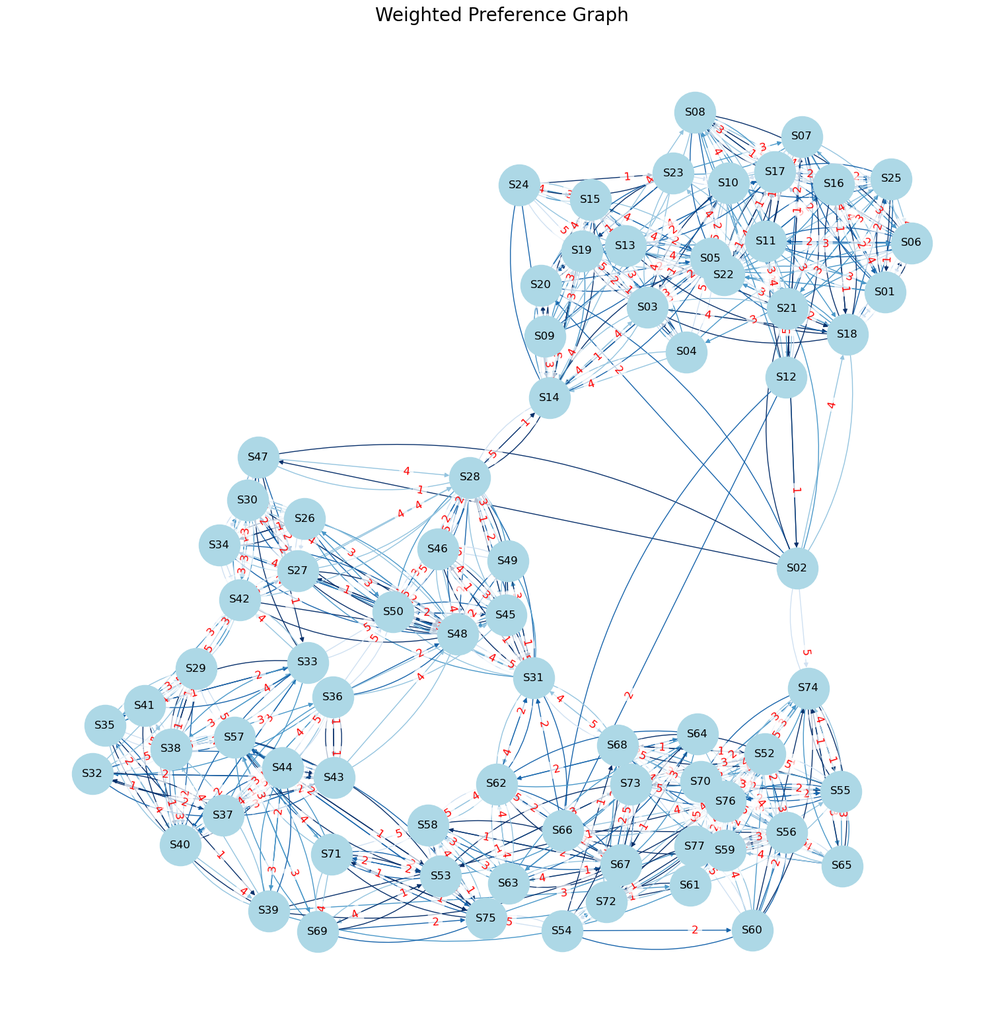

```python
G = nx.DiGraph()
weights = {1: 5, 2: 4, 3: 3, 4: 2, 5: 1}
choice = {1: 1, 2: 2, 3: 3, 4: 4, 5: 5}

# Add edges with weights
for _, row in preferences.iterrows():
    student = row["ID"]
    for i in range(1, 6):  # Adjust if you have more preferences
        preferred_student = row[f"Preference_{i}"]
        if pd.notna(preferred_student):
            G.add_edge(student, preferred_student, weight=weights[i], choice=choice[i])

# Get edge weights for visualization
edges, edge_weights = zip(*nx.get_edge_attributes(G, "weight").items())
edge_colors = [plt.cm.Blues(w / max(edge_weights)) for w in edge_weights]

# Draw the graph
plt.figure(figsize=(15, 15))
pos = nx.kamada_kawai_layout(G)
nx.draw(G, pos, with_labels=True, node_color='lightblue', edge_color=edge_colors,
         edge_cmap=plt.cm.Blues, arrows=True, node_size=2000)

# # Draw curved edges
nx.draw_networkx_edges(G, pos, edge_color=edge_colors, connectionstyle="arc3,rad=0.2", arrows=True)

# Draw edge labels with background
edge_labels = {(u, v): w for u, v, w in G.edges.data("choice")}
nx.draw_networkx_edge_labels(G, pos, edge_labels=edge_labels, font_size=12, font_color='red',
    bbox=dict(facecolor="white", edgecolor="none", alpha=0.7), label_pos=0.3)

plt.title("Weighted Preference Graph", fontsize=20)
plt.show()
```

### 4. Baseline model

```python
def assign_students_randomly(student_info, constraints, num_groups=3, seed=42):
    # Set seed for reproducibility
    random.seed(seed)

    groups = {i: [] for i in range(num_groups)}
    include_constraints = {}
    exclude_constraints = {}

    for _, row in constraints.iterrows():
        s1, s2 = row['Student_1'], row['Student_2']
        if row['Constraint'] == 'Include':
            include_constraints.setdefault(s1, []).append(s2)
            include_constraints.setdefault(s2, []).append(s1)
        elif row['Constraint'] == 'Exclude':
            exclude_constraints.setdefault(s1, []).append(s2)
            exclude_constraints.setdefault(s2, []).append(s1)

    # Shuffle students for randomness
    students = student_info.sample(frac=1, random_state=seed).reset_index(drop=True)


    assigned = {}
    # Assign students while considering constraints
    for _, student in students.iterrows():
        student_id = student['ID']
        possible_groups = list(groups.keys())

        # Ensure no exclusions
        for group_id in possible_groups[:]:
            if any(ex in groups[group_id] for ex in exclude_constraints.get(student_id, [])):
                possible_groups.remove(group_id)

        # Assign to least populated valid group
        chosen_group = min(possible_groups, key=lambda g: len(groups[g]))
        groups[chosen_group].append(student_id)
        assigned[student_id] = chosen_group

        # Ensure inclusions
        for inc in include_constraints.get(student_id, []):
            if inc in assigned:
                continue
            groups[chosen_group].append(inc)
            assigned[inc] = chosen_group

    result = pd.DataFrame([(s, g) for g, students in groups.items() for s in students],
                          columns=['ID', 'Assigned_Group'])

    return result


assigned_groups = assign_students_randomly(student_info, constraints, seed=48)
print(assigned_groups)

# Save the assigned groups to a CSV file
assigned_groups.to_csv('assigned_groups.csv', index=False)
```

```
     ID  Assigned_Group
0   S11               0
1   S09               0
2   S34               0
3   S39               0
4   S42               0
..  ...             ...
72  S29               2
73  S47               2
74  S35               2
75  S71               2
76  S69               2

[77 rows x 2 columns]
```

```python
# Load the assigned groups from the CSV file
assigned_groups = pd.read_csv('assigned_groups.csv')

# Merge student_info with assigned_groups
merged = student_info.merge(assigned_groups, on='ID')

# Count the number of students in each group
group_counts = assigned_groups['Assigned_Group'].value_counts().sort_index()

# Count gender in each Assigned_Group
gender_counts = merged.groupby("Assigned_Group")["Gender"].value_counts().unstack().fillna(0)

# Count Group (4/5) in each Assigned_Group
group_counts = merged.groupby("Assigned_Group")["Group"].value_counts().unstack().fillna(0)

print("Number of students in each group:")
print(group_counts)

print("Gender count per assigned group:")
print(gender_counts)

print("\nGroup count per assigned group:")
print(group_counts)
```

```
Number of students in each group:
Group            4   5
Assigned_Group
0               12  14
1               14  12
2               14  11
Gender count per assigned group:
Gender           f   m
Assigned_Group
0               10  16
1               12  14
2               12  13

Group count per assigned group:
Group            4   5
Assigned_Group
0               12  14
1               14  12
2               14  11
```

### 5. Define metrics

##### Check for constraint violations

```python
def valid_group(assigned_groups, constraints):
    n_violations = 0
    n_no_violations = 0

    # Convert constraints to a lookup dictionary
    include_constraints = {}
    exclude_constraints = {}

    for _, row in constraints.iterrows():
        s1, s2 = row['Student_1'], row['Student_2']
        if row['Constraint'] == 'Include':
            include_constraints.setdefault(s1, []).append(s2)
            include_constraints.setdefault(s2, []).append(s1)
        elif row['Constraint'] == 'Exclude':
            exclude_constraints.setdefault(s1, []).append(s2)
            exclude_constraints.setdefault(s2, []).append(s1)

    # Check for violated constraints
    for _, row in assigned_groups.iterrows():
        student_id = row['ID']
        group_id = row['Assigned_Group']

        # Check for exclusions
        for ex in exclude_constraints.get(student_id, []):
            # Ensure we're checking pairs in both directions to avoid duplicate checks
            if student_id < ex:
                if ex in assigned_groups[assigned_groups['Assigned_Group'] == group_id]['ID'].values:
                    n_violations += 1
                else:
                    n_no_violations += 1

        # Check for inclusions
        for inc in include_constraints.get(student_id, []):
            # Ensure we're checking pairs in both directions to avoid duplicate checks
            if student_id < inc:
                if inc not in assigned_groups[assigned_groups['Assigned_Group'] == group_id]['ID'].values:
                    n_violations += 1
                else:
                    n_no_violations += 1

    return n_violations, n_no_violations

# Check for violated constraints
violations, no_violations = valid_group(assigned_groups, constraints)
print('Number of constraints violated:', violations)
print('Number of constraints not violated:', no_violations)
```

```
Number of constraints violated: 0
Number of constraints not violated: 11
```

##### Check if the groups are balanced

There are two ways to assess balance:

1. **Balancing Categories Across Groups**

   This method checks if each category (e.g., gender) is proportionally distributed among the groups.
2. **Balancing Within Groups**

   This method ensures that each group maintains an internal balance for a given category. Instead of comparing groups to each other, it checks whether each group has a similar distribution of the category (e.g., an even mix of genders).

Both methods use a threshold to determine the acceptable range of deviation from perfect balance. If the deviation exceeds the threshold, the balance constraint is violated.

```python
# Get balance of a categorical variable across groups
def get_balance_column(merged, column):
    # Get counts of the variable by group
    counts = merged.groupby('Assigned_Group')[column].value_counts().unstack().fillna(0)
    total = counts.sum(axis=0)
    percentage = counts.div(total)
    return percentage

# Check if each category in a categorical variable is balanced
def is_balanced_column(merged, column, threshold=0.1):
    # Get the percentages for each category in the column
    percentages = get_balance_column(merged, column)

    # Loop through each category in the column
    for category in percentages.columns:
        # Get the difference between the max and min percentage for the category
        difference = percentages[category].max() - percentages[category].min()

        # Check if the difference is within the threshold
        if difference <= threshold:
            print(f"{category} is balanced.")
        else:
            print(f"{category} is not balanced.")


is_balanced_column(merged, 'Gender')
is_balanced_column(merged, 'Group')
```

```
f is balanced.
m is balanced.
4 is balanced.
5 is balanced.
```

```python
def get_balance_category(merged, column):
    # Get counts of the variable by group
    counts = merged.groupby('Assigned_Group')[column].value_counts().unstack().fillna(0)
    total = counts.sum(axis=1)
    percentage = counts.div(total, axis=0)
    return percentage

def check_balance_category(merged, column, threshold=0.1):
    percentages = get_balance_category(merged, column)
    print(f"Balance of {column} across groups:")

    for group in percentages.index:
        difference = percentages.loc[group].max() - percentages.loc[group].min()

        if difference <= threshold:
            print(f"Group {group} is balanced.")
        else:
            print(f"Group {group} is not balanced.")

check_balance_category(merged, 'Gender')
check_balance_category(merged, 'Group')
```

```
Balance of Gender across groups:
Group 0 is not balanced.
Group 1 is balanced.
Group 2 is balanced.
Balance of Group across groups:
Group 0 is balanced.
Group 1 is balanced.
Group 2 is not balanced.
```

##### Check how well the students are grouped based on their preferences

```python
def calculate_optimal_score(preferences_df):
    optimal_score = 0

    # Loop through each student and calculate the maximum possible score based on their preferences
    for _, row in preferences_df.iterrows():
        preferences = row[['Preference_1', 'Preference_2', 'Preference_3', 'Preference_4', 'Preference_5']].dropna().tolist()
        student_max_score = sum([5 - i for i in range(len(preferences))])
        optimal_score += student_max_score

    return optimal_score

# Calculate the optimal score
optimal_score = calculate_optimal_score(preferences)
print('Optimal score:', optimal_score)
```

```
Optimal score: 1133
```

```python
def evaluate_accuracy_from_csv(assigned_groups, preferences_df):
    total_points = 0
    student_groups = assigned_groups.set_index('ID')['Assigned_Group'].to_dict()

    for _, row in preferences_df.iterrows():
        student_id = row['ID']
        preferences = row[['Preference_1', 'Preference_2', 'Preference_3', 'Preference_4', 'Preference_5']].dropna().tolist()

        assigned_group = student_groups.get(student_id)

        student_score = 0
        for i, preferred_student in enumerate(preferences):
            if preferred_student in student_groups and student_groups[preferred_student] == assigned_group:
                student_score += (5 - i)

        total_points += student_score

    optimal_score = calculate_optimal_score(preferences_df)

    if optimal_score == 0:
        relative_excess = 0
    else:
        relative_excess = (optimal_score - total_points) / optimal_score * 100

    absolute_difference = optimal_score - total_points
    return total_points, optimal_score, relative_excess, absolute_difference


# Evaluate the accuracy
total_points, optimal_score, relative_excess, absolute_difference = evaluate_accuracy_from_csv(assigned_groups, preferences)

print("Total Points:", total_points)
print("Optimal Score:", optimal_score)
print("Absolute Difference:", absolute_difference)
print("Relative Excess (%):", relative_excess)
```

```
Total Points: 348
Optimal Score: 1133
Absolute Difference: 785
Relative Excess (%): 69.28508384819064
```

```python
preferences_with_groups = pd.merge(preferences, assigned_groups[['ID', 'Assigned_Group']], on='ID')
preferences_in_same_group_count = {}

# Loop through each kid (each row in the preferences DataFrame)
for i1, row in preferences_with_groups.iterrows():
    group_of_kid = row['Assigned_Group']
    kid_preferences = [row[f'Preference_{i}'] for i in range(1, 6)]

    count = 0
    for kid in kid_preferences:
        if pd.isnull(kid):
            continue

        if preferences_with_groups[preferences_with_groups['ID'] == kid]['Assigned_Group'].values[0] == group_of_kid:
            count += 1

    preferences_in_same_group_count[row['ID']] = count

preferences_in_same_group_df = pd.DataFrame(list(preferences_in_same_group_count.items()), columns=['ID', 'Preferences_In_Same_Group'])
preferences_in_same_group_df
```

|  | ID | Preferences_In_Same_Group |
| --- | --- | --- |
| 0 | S01 | 3 |
| 1 | S02 | 1 |
| 2 | S03 | 2 |
| 3 | S04 | 0 |
| 4 | S05 | 3 |
| ... | ... | ... |
| 72 | S73 | 1 |
| 73 | S74 | 1 |
| 74 | S75 | 0 |
| 75 | S76 | 2 |
| 76 | S77 | 1 |

77 rows × 2 columns

Function to check if every kid has been sorted with at least 'n' preferences

```python
def check_preferences_sorted(preferences_in_same_group_df, n):
    valid_kids = preferences_in_same_group_df[preferences_in_same_group_df['Preferences_In_Same_Group'] >= n]

    return valid_kids['ID'].tolist()

# Check for at least 1 preference
at_least_1_pref = check_preferences_sorted(preferences_in_same_group_df, 1)
print("At least 1 preference:", at_least_1_pref)

# Check for at least 2 preferences
at_least_2_prefs = check_preferences_sorted(preferences_in_same_group_df, 2)
print("At least 2 preferences:", at_least_2_prefs)

# Check for at least 3 preferences
at_least_3_prefs = check_preferences_sorted(preferences_in_same_group_df, 3)
print("At least 3 preferences:", at_least_3_prefs)

# Check for at least 4 preferences
at_least_4_prefs = check_preferences_sorted(preferences_in_same_group_df, 4)
print("At least 4 preferences:", at_least_4_prefs)

# Check for at least 5 preferences
at_least_5_prefs = check_preferences_sorted(preferences_in_same_group_df, 5)
print("At least 5 preferences:", at_least_5_prefs)
```

[output not shown]

```python
print('Every student has been sorted with at least 1 preference:', len(at_least_1_pref) == n_students)
print('Every student has been sorted with at least 2 preferences:', len(at_least_2_prefs) == n_students)
print('Every student has been sorted with at least 3 preferences:', len(at_least_3_prefs) == n_students)
print('Every student has been sorted with at least 4 preferences:', len(at_least_4_prefs) == n_students)
print('Every student has been sorted with at least 5 preferences:', len(at_least_5_prefs) == n_students)
```

```
Every student has been sorted with at least 1 preference: False
Every student has been sorted with at least 2 preferences: False
Every student has been sorted with at least 3 preferences: False
Every student has been sorted with at least 4 preferences: False
Every student has been sorted with at least 5 preferences: False
```